# Projet de contrôle qualité

Erivan INAN, M2 ISDS, 2025

```
                                                           PROJET
```

**————————————————————– IMPORTATION DES LIBRAIRIES NÉCESSAIRES ————————————————————-**

```r
# bibliothèques nécessaires
library(ggplot2) # pour l'affichage des graphes
library(qcc) # pour les cartes de contrôle
```

**——————————————————————————– Présentation du projet ——————————————————————————-**

**—————————————————————————— Chargement des données —————————————————————————–**

```r
# Chargement des données
df_2023 <- read.csv("C:/Users/beriv/2023_CO.csv", header=TRUE, sep=",", stringsAsFactors=FALSE)
df_2024 <- read.csv("C:/Users/beriv/2024_CO.csv", header=TRUE, sep=",", stringsAsFactors=FALSE)

# Vérification des premières lignes
head(df_2023)
```

|  | Date | CO |
| --- | --- | --- |
| 1 | 2023-01-01 01:00:00Z | 0.142 |
| 2 | 2023-01-01 02:00:00Z | 0.140 |
| 3 | 2023-01-01 03:00:00Z | 0.136 |
| 4 | 2023-01-01 04:00:00Z | 0.130 |
| 5 | 2023-01-01 05:00:00Z | 0.136 |
| 6 | 2023-01-01 06:00:00Z | 0.133 |

```r
head(df_2024)
```

|  | Date | CO |
| --- | --- | --- |
| 1 | 2024-01-01 01:00:00Z | 0.175 |
| 2 | 2024-01-01 02:00:00Z | 0.168 |
| 3 | 2024-01-01 03:00:00Z | 0.161 |
| 4 | 2024-01-01 04:00:00Z | 0.154 |
| 5 | 2024-01-01 05:00:00Z | 0.154 |
| 6 | 2024-01-01 06:00:00Z | 0.152 |

```r
# Convertir CO en numérique après la séparation
df_2023$CO <- as.numeric(df_2023$CO)
df_2024$CO <- as.numeric(df_2024$CO)
```

**————————————————————————————— Question 1 ————————————————————————————–**

Commençons par estimer la moyenne et la variance de nos données de 2023 et 2024, grâce aux estimateurs empiriques bien connus :

- Estimateur empirique de la moyenne $\hat{\mu}$

$$\hat{\mu} = \frac{1}{n} \sum_{i=1}^{n} X_i$$

- Estimateur empirique de la variance $\hat{\sigma}^2$

$$\hat{\sigma}^2 = \frac{1}{n-1} \sum_{i=1}^{n} (X_i - \hat{\mu})^2$$

```r
# --- CALCUL MANUEL DE LA MOYENNE ET VARIANCE ---
n_2023 <- sum(!is.na(df_2023$CO))
n_2024 <- sum(!is.na(df_2024$CO))

moy_2023 <- sum(df_2023$CO, na.rm=TRUE) / n_2023
moy_2024 <- sum(df_2024$CO, na.rm=TRUE) / n_2024

var_2023 <- sum((df_2023$CO - moy_2023)^2, na.rm=TRUE) / (n_2023 - 1)
var_2024 <- sum((df_2024$CO - moy_2024)^2, na.rm=TRUE) / (n_2024 - 1)

cat("Moyenne du monoxyde de carbone en 2023:", moy_2023, "\n")
```

```
## Moyenne du monoxyde de carbone en 2023: 0.2087222
```

```r
cat("Variance du monoxyde de carbone en 2023:", var_2023, "\n")
```

```
## Variance du monoxyde de carbone en 2023: 0.01192399
```

```r
cat("Moyenne du monoxyde de carbone en 2024:", moy_2024, "\n")
```

```
## Moyenne du monoxyde de carbone en 2024: 0.20126
```

```r
cat("Variance du monoxyde de carbone en 2024:", var_2024, "\n")
```

```
## Variance du monoxyde de carbone en 2024: 0.008982847
```

Affichons leurs distributions pour juger de l’état général de nos datasets :

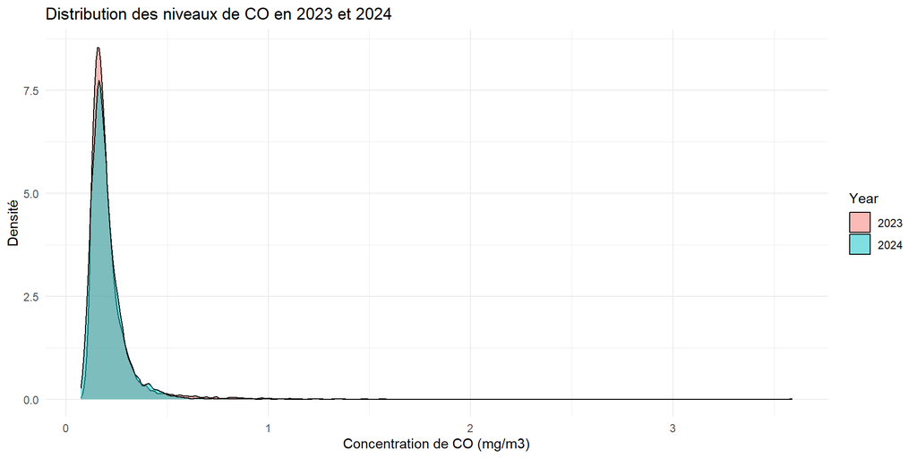

```r
# Graphe des distributions

df_2023$Year <- "2023"
df_2024$Year <- "2024"
df_all <- rbind(df_2023, df_2024)

ggplot(na.omit(df_all), aes(x=CO, fill=Year)) +
  geom_density(alpha=0.5) +
  ggtitle("Distribution des niveaux de CO en 2023 et 2024") +
  xlab("Concentration de CO (mg/m3)") +
  ylab("Densité") +
  theme_minimal()
```

**————————————————————————————— Question 2 ————————————————————————————–**

Puis on réalise un test de Student sur la moyenne avec les hypothèses suivantes :

- $H_0$ : Les moyennes de 2023 et 2024 sont égales
- $H_1$ : Les moyennes de 2023 et 2024 sont différentes

```r
t_test_result <- t.test(df_2023$CO, df_2024$CO, alternative="two.sided", var.equal=FALSE)
cat("\nTest t de Student pour comparer les moyennes:\n")
```

```
##
## Test t de Student pour comparer les moyennes:
```

```r
print(t_test_result)
```

```
##
##  Welch Two Sample t-test
##
## data:  df_2023$CO and df_2024$CO
## t = 4.7864, df = 16793, p-value = 1.712e-06
## alternative hypothesis: true difference in means is not equal to 0
## 95 percent confidence interval:
##  0.004406313 0.010517990
## sample estimates:
## mean of x mean of y
## 0.2087222 0.2012600
```

La p-value est extrêmement faible, inférieure à 0.05, donc on rejette $H_0$, et il y a une différence significative entre les moyennes des niveaux de monoxyde de carbone (CO) en 2023 et 2024.

Effectuons un test de Fisher de la variance, avec les hypothèses suivantes :

- $H_0$ : Les variances de 2023 et 2024 sont égales
- $H_1$ : Les variances de 2023 et 2024 sont différentes

```r
var_test_result <- var.test(df_2023$CO, df_2024$CO)
cat("\nTest de Fisher (F-test) pour comparer les variances:\n")
```

```
##
## Test de Fisher (F-test) pour comparer les variances:
```

```r
print(var_test_result)
```

```
##
##  F test to compare two variances
##
## data:  df_2023$CO and df_2024$CO
## F = 1.3274, num df = 8526, denom df = 8702, p-value < 2.2e-16
## alternative hypothesis: true ratio of variances is not equal to 1
## 95 percent confidence interval:
##  1.272521 1.384696
## sample estimates:
## ratio of variances
##           1.327418
```

De même que pour le test sur la moyenne, la p-value du test de Fisher est extrêmement faible, inférieure à 0.05, donc on rejette $H_0$, et il y a une différence significative entre les variances des niveaux de monoxyde de carbone (CO) en 2023 et 2024.

**————————————————————————————— Question 3 ————————————————————————————–**

La médiane peut être estimée par la médiane empirique $\tilde{X}$, définie pour un échantillon de taille $n$ comme étant :

- Si $n$ est impair :
  $$\tilde{X} = X_{\frac{n+1}{2}}$$
- Si $n$ est pair :
  $$\tilde{X} = \frac{X_{\frac{n}{2}} + X_{\frac{n}{2} + 1}}{2}$$

où $X_i$ sont les valeurs triées de l’échantillon

```r
tri_2023 <- sort(df_2023$CO, na.last=NA)
tri_2024 <- sort(df_2024$CO, na.last=NA)

n_2023 <- length(tri_2023)
n_2024 <- length(tri_2024)

# Calcul de la médiane à l'aide de la formule de l'estimateur ci-dessus
mediane_2023 <- if (n_2023 %% 2 == 1) {
  tri_2023[(n_2023 + 1) / 2] # si n impair
} else {
  (tri_2023[n_2023 / 2] + tri_2023[n_2023 / 2 + 1]) / 2 # si n pair
}

mediane_2024 <- if (n_2024 %% 2 == 1) {
  tri_2024[(n_2024 + 1) / 2] # si n impair
} else {
  (tri_2024[n_2024 / 2] + tri_2024[n_2024 / 2 + 1]) / 2 # si n pair
}

# Résultats
cat("Médiane estimée pour 2023 :", mediane_2023, "\n")
```

```
## Médiane estimée pour 2023 : 0.18
```

```r
cat("Médiane estimée pour 2024 :", mediane_2024, "\n")
```

```
## Médiane estimée pour 2024 : 0.181
```

Pour valider les médianes qu’on a estimés (hypothétiques), on propose de réaliser un test du signe, une alternative simple au test de Wilcoxon et permet de tester si la médiane d’un échantillon est égale à une valeur hypothétique.

Les hypothèses sont les suivantes :

- $H_0$ : la médiane de l’échantillon est égale à la médiane théorique $m_0$
- $H_1$ : la médiane est différente de $m_0$

```r
tri_2023 <- data.frame(CO = tri_2023)  # Convertir en dataframe
tri_2024 <- data.frame(CO = tri_2024)

# Test du signe
test_signe_2023 <- binom.test(sum(tri_2023$CO > mediane_2023, na.rm=TRUE),
                             sum(!is.na(tri_2023$CO)),
                             p=0.5, alternative="two.sided")

test_signe_2024 <- binom.test(sum(tri_2024$CO > mediane_2024, na.rm=TRUE),
                             sum(!is.na(tri_2024$CO)),
                             p=0.5, alternative="two.sided")

# --- AFFICHAGE DES RÉSULTATS ---
cat("\nTest du Signe pour 2023 :\n")
```

```
##
## Test du Signe pour 2023 :
```

```r
print(test_signe_2023)
```

```
##
##  Exact binomial test
##
## data:  sum(tri_2023$CO > mediane_2023, na.rm = TRUE) and sum(!is.na(tri_2023$CO))
## number of successes = 4235, number of trials = 8527, p-value = 0.5442
## alternative hypothesis: true probability of success is not equal to 0.5
## 95 percent confidence interval:
##  0.4859894 0.5073282
## sample estimates:
## probability of success
##              0.4966577
```

```r
cat("\nTest du Signe pour 2024 :\n")
```

```
##
## Test du Signe pour 2024 :
```

```r
print(test_signe_2024)
```

```
##
##  Exact binomial test
##
## data:  sum(tri_2024$CO > mediane_2024, na.rm = TRUE) and sum(!is.na(tri_2024$CO))
## number of successes = 4325, number of trials = 8703, p-value = 0.5773
## alternative hypothesis: true probability of success is not equal to 0.5
## 95 percent confidence interval:
##  0.4863956 0.5075166
## sample estimates:
## probability of success
##              0.4969551
```

Les résultats du test du signe montrent que la médiane empirique est un bon estimateur de la tendance centrale.

**————————————————————————————— Question 4 ————————————————————————————–**

Le quantile à 90% est défini comme la valeur telle que 90% des observations soient inférieures ou égales à cette valeur.

Si $X_1, X_2, \dots, X_n$ sont les observations triées, alors le quantile d’ordre $p$ est donné par :

$$Q_p = X_{\lfloor p \times n \rfloor}$$

où $p = 0.90$ pour le 90ème quantile et $\lfloor . \rfloor$ représente la partie entière.

Calculons les estimateurs du 90ème quantile :

```r
p <- 0.90  # quantile à 90%

k_2023 <- floor(p * n_2023 + 0.5)
k_2024 <- floor(p * n_2024 + 0.5)

w_2023 <- (p * n_2023 + 0.5) - k_2023
w_2024 <- (p * n_2024 + 0.5) - k_2024

quantile_90_2023 <- (1 - w_2023) * tri_2023$CO[k_2023] + w_2023 * tri_2023$CO[min(k_2023 + 1, n_2023)]
quantile_90_2024 <- (1 - w_2024) * tri_2024$CO[k_2024] + w_2024 * tri_2024$CO[min(k_2024 + 1, n_2024)]

# Résultats
cat("90ᵉ Quantile 2023 (estimateur) :", quantile_90_2023, "\n")
```

```
## 90ᵉ Quantile 2023 (estimateur) : 0.302
```

```r
cat("90ᵉ Quantile 2024 (estimateur) :", quantile_90_2024, "\n")
```

```
## 90ᵉ Quantile 2024 (estimateur) : 0.295
```

Pour valider les quantiles qu’on a estimés (hypothétiques), on propose de réaliser un test du signe, une alternative simple au test de Wilcoxon et permet de tester si la médiane d’un échantillon est égale à une valeur hypothétique.

Les hypothèses sont les suivantes :

- $H_0$ : Le quantile estimé est bien positionné, c’est-à-dire 90%
- $H_1$ : Le quantile estimé est biaisé, donc la proportion des valeurs supérieures n’est pas égale à 10%.

```r
test_signe_90_2023 <- binom.test(sum(tri_2023$CO > quantile_90_2023, na.rm=TRUE),
                                sum(!is.na(tri_2023$CO)),
                                p=0.10, alternative="two.sided")

test_signe_90_2024 <- binom.test(sum(tri_2024$CO > quantile_90_2024, na.rm=TRUE),
                                sum(!is.na(tri_2024$CO)),
                                p=0.10, alternative="two.sided")


# Résultats
cat("\nTest du Signe pour le 90ᵉ Quantile en 2023 :\n")
```

```
##
## Test du Signe pour le 90ᵉ Quantile en 2023 :
```

```r
print(test_signe_90_2023)
```

```
##
##  Exact binomial test
##
## data:  sum(tri_2023$CO > quantile_90_2023, na.rm = TRUE) and sum(!is.na(tri_2023$CO))
## number of successes = 847, number of trials = 8527, p-value = 0.8568
## alternative hypothesis: true probability of success is not equal to 0.1
## 95 percent confidence interval:
##  0.09306201 0.10587632
## sample estimates:
## probability of success
##             0.09933154
```

```r
cat("\nTest du Signe pour le 90ᵉ Quantile en 2024 :\n")
```

```
##
## Test du Signe pour le 90ᵉ Quantile en 2024 :
```

```r
print(test_signe_90_2024)
```

```
##
##  Exact binomial test
##
## data:  sum(tri_2024$CO > quantile_90_2024, na.rm = TRUE) and sum(!is.na(tri_2024$CO))
## number of successes = 869, number of trials = 8703, p-value = 0.9857
## alternative hypothesis: true probability of success is not equal to 0.1
## 95 percent confidence interval:
##  0.09362926 0.10634131
## sample estimates:
## probability of success
##             0.09985063
```

En 2023 (p = 0.8568) et 2024 (p = 0.9857), les p-values sont bien supérieures à 0.05. On ne peut donc pas rejeter $H_0$, et l’estimation du 90ème quantile est correcte.

**————————————————————————————— Question 5 ————————————————————————————–**

Le test de Cox et Stuart est un test non paramétrique utilisé pour détecter une tendance monotone dans une série temporelle, ici les séries des quantités de monoxyde de carbonne libérées en 2023 et en 2024. Ce tets est basé sur un test du signe appliqué aux valeurs de la série prises de manière symétrique autour du centre.

Voici les hypothèses du test :

- $H_0$ : Pas de tendance monotone dans la série temporelle
- $H_1$ : Il existe une tendance monotone significative dans la série temporelle

L’idée est de découper la série $X_1, X_2, X_3, ... , X_n$ en deux moitiés selon la parité des indices des valeurs et d’appliquer un test du signe sur la différence des valeurs.

```r
tri_2023 <- data.frame(CO = tri_2023)  # conversion en dataframe
tri_2024 <- data.frame(CO = tri_2024)

# Test de Cox et Stuart
test_cox_stuart <- function(serie) {
  serie <- na.omit(serie)  # supprime les valeurs manquantes
  taille <- length(serie)

  # on ajuste pour les séries de taille impaire : on supprime le dernier élément
  if (taille %% 2 == 1) {
    serie <- serie[-taille]
    taille <- length(serie)
  }

  k <- taille / 2  # moitié de la série
  premiere_moitie <- serie[1:k]  # première moitié
  deuxieme_moitie <- serie[(k+1):taille]  # deuxième moitié

  # Calcul des différences entre les deux moitiés
  differences <- deuxieme_moitie - premiere_moitie

  # Comptage des signes positifs et négatifs
  nb_positifs <- sum(differences > 0, na.rm=TRUE)
  nb_negatifs <- sum(differences < 0, na.rm=TRUE)

  # Application du test binomial sous H0 (répartition aléatoire des signes)
  test_signe <- binom.test(nb_positifs, nb_positifs + nb_negatifs, p=0.5, alternative="two.sided")

  return(test_signe)
}

# Test
resultat_cox_stuart_2023 <- test_cox_stuart(tri_2023$CO)
resultat_cox_stuart_2024 <- test_cox_stuart(tri_2024$CO)

# Résultats
cat("\nTest de Cox et Stuart pour 2023 :\n")
```

```
##
## Test de Cox et Stuart pour 2023 :
```

```r
print(resultat_cox_stuart_2023)
```

```
##
##  Exact binomial test
##
## data:  nb_positifs and nb_positifs + nb_negatifs
## number of successes = 4263, number of trials = 4263, p-value < 2.2e-16
## alternative hypothesis: true probability of success is not equal to 0.5
## 95 percent confidence interval:
##  0.999135 1.000000
## sample estimates:
## probability of success
##                      1
```

```r
cat("\nTest de Cox et Stuart pour 2024 :\n")
```

```
##
## Test de Cox et Stuart pour 2024 :
```

```r
print(resultat_cox_stuart_2024)
```

```
##
##  Exact binomial test
##
## data:  nb_positifs and nb_positifs + nb_negatifs
## number of successes = 4351, number of trials = 4351, p-value < 2.2e-16
## alternative hypothesis: true probability of success is not equal to 0.5
## 95 percent confidence interval:
##  0.9991525 1.0000000
## sample estimates:
## probability of success
##                      1
```

**————————————————————————————— Question 6 ————————————————————————————–**

Le test des rangs signés de Wilcoxon avec prise en compte des ex-aequos est un test non paramétrique qui permet d’évaluer si une série de valeurs suit une distribution centrée autour de zéro ou présente un décalage significatif.

**Étapes du test :**

1. On calcule les différences absolues $ D_i = X_i - m_0 $
2. Classement des valeurs absolues : on attribue les rangs $R_i$
3. Gestion des ex-aequos : pour les valeurs identiques, on fait la moyenne des rangs
4. On calcule la statistique de test :
5. On calcule l’espérance et la variance :
6. On compare avec une distribution de Wilcoxon

```r
# Choix de la médiane théorique m0
m0_2023 <- median(df_2023$CO, na.rm=TRUE)
m0_2024 <- median(df_2024$CO, na.rm=TRUE)

# Étape 1) On calcule les différences absolues
D_2023 <- df_2023$CO - m0_2023
D_2024 <- df_2024$CO - m0_2024

D_2023 <- D_2023[D_2023 != 0] # suppression des valeurs nulles dans D
D_2024 <- D_2024[D_2024 != 0]


# Étape 3) Gestion des ex-aequos : pour les valeurs identiques, on fait la moyenne des rangs

rangs_2023 <- rank(abs(D_2023), ties.method="average")  # gestion des ex-aequos
rangs_2024 <- rank(abs(D_2024), ties.method="average")

t_l_2023 <- table(rangs_2023) # calcul des groupes de rangs
t_l_2024 <- table(rangs_2024)

# Étape 4) On calcule la statistique de test T
T_2023 <- sum(as.numeric(names(t_l_2023))^2 * (as.numeric(t_l_2023) - 1))
T_2024 <- sum(as.numeric(names(t_l_2024))^2 * (as.numeric(t_l_2024) - 1))

# Étape 5) On calcule l'espérance et la variance
n_2023 <- length(D_2023)
n_2024 <- length(D_2024)

E_T_2023 <- (n_2023 + 1) / 2
Var_T_2023 <- (n_2023^2 - 1) / 12

E_T_2024 <- (n_2024 + 1) / 2
Var_T_2024 <- (n_2024^2 - 1) / 12

Z_2023 <- (T_2023 - E_T_2023) / sqrt(Var_T_2023) # normalisation de la statistique T
Z_2024 <- (T_2024 - E_T_2024) / sqrt(Var_T_2024)

# Étape 6) On compare avec une distribution de Wilcoxon  N(0,1)
p_value_2023 <- 2 * (1 - pnorm(abs(Z_2023)))
p_value_2024 <- 2 * (1 - pnorm(abs(Z_2024)))

# Résultats
cat("\nTest des rangs signés de Wilcoxon pour 2023 :\n")
```

```
##
## Test des rangs signés de Wilcoxon pour 2023 :
```

```r
cat("Statistique T :", T_2023, "\nEspérance E(T) :", E_T_2023, "\nVariance Var(T) :", Var_T_2023, "\nZ :", Z_2023, "\nP-value :", p_value_2023, "\n")
```

```
## Statistique T : 173262598614
## Espérance E(T) : 4350.5
## Variance Var(T) : 6307500
## Z : 68988418
## P-value : 0
```

```r
cat("\nTest des rangs signés de Wilcoxon pour 2024 :\n")
```

```
##
## Test des rangs signés de Wilcoxon pour 2024 :
```

```r
cat("Statistique T :", T_2024, "\nEsperance E(T) :", E_T_2024, "\nVariance Var(T) :", Var_T_2024, "\nZ :", Z_2024, "\nP-value :", p_value_2024, "\n")
```

```
## Statistique T : 1.913e+11
## Esperance E(T) : 4368.5
## Variance Var(T) : 6359808
## Z : 75856542
## P-value : 0
```

Les résultats des test des rangs signés de Wilcoxon indique une forte asymétrie dans la distribution des niveaux de CO en 2023 et 2024.

On peut le confirmer en affichant le boxplot et l’histogramme des niveaux de CO :

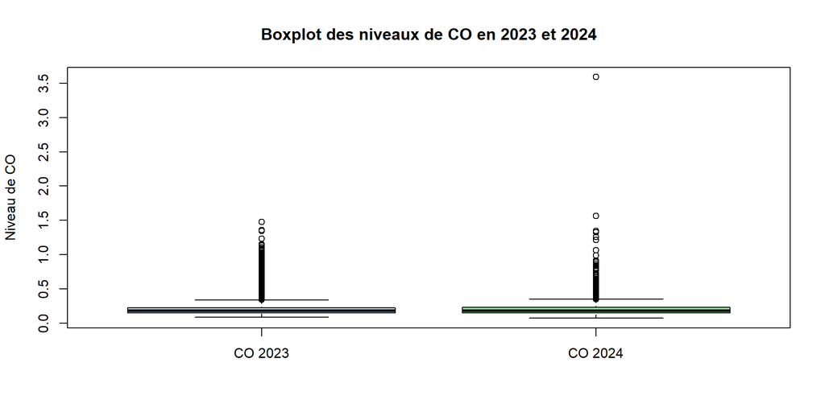

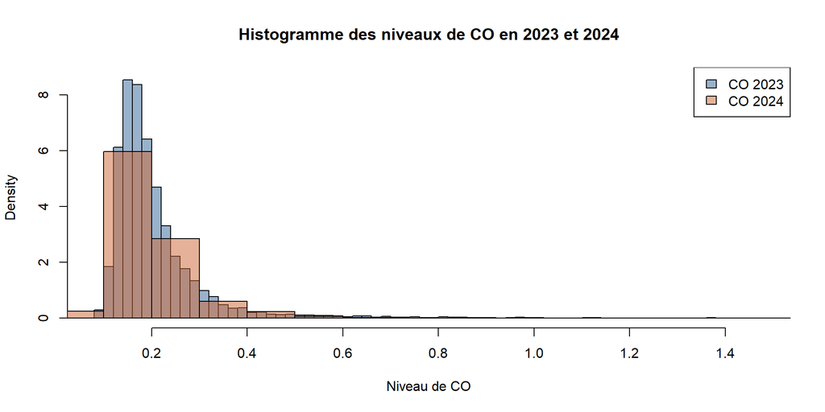

```r
# conversion en data frames si nécessaire
df_2023 <- as.data.frame(df_2023)
df_2024 <- as.data.frame(df_2024)

# on supprime les valeurs NA
df_2023 <- na.omit(df_2023)
df_2024 <- na.omit(df_2024)

# Boxplot
boxplot(df_2023$CO, df_2024$CO,
        names = c("CO 2023", "CO 2024"),
        main = "Boxplot des niveaux de CO en 2023 et 2024",
        ylab = "Niveau de CO", col = c("lightblue", "lightgreen"),
        outline = TRUE) # Garde les valeurs extrêmes

# Histogramme
hist(df_2023$CO, breaks = 50, col=rgb(0.2,0.4,0.6,0.5),
     xlab="Niveau de CO", main="Histogramme des niveaux de CO en 2023 et 2024",
     probability=TRUE, ylim=c(0, max(density(df_2023$CO)$y, density(df_2024$CO)$y)))

hist(df_2024$CO, breaks = 50, col=rgb(0.8,0.4,0.2,0.5),
     add=TRUE, probability=TRUE)

legend("topright", legend=c("CO 2023", "CO 2024"),
       fill=c(rgb(0.2,0.4,0.6,0.5), rgb(0.8,0.4,0.2,0.5)))
```

L’histogramme confirme l’asymétrie détectée par le test de Wilcoxon.En effet, les valeurs de monoxyde de carbone (CO) sont distribuées de manière non symétrique, avec une forte concentration autour de 0.1 - 0.3 et une traîne droite.

**————————————————————————————— Question 7 ————————————————————————————–**

Appliquons le test des rangs signés de Wilcoxon pour tester si la médiane des niveaux de CO diffère significativement d’une valeur hypothétique $m_0$.

Voici les hypothèses du test :

- $H_0$ : La médiane des niveaux de CO est égale à $m_0$
- $H_1$ : La médiane des niveaux de CO est différente de $m_0$

```r
# calcul de la médiane
mediane_obs_2023 <- median(df_2023$CO, na.rm=TRUE)
mediane_obs_2024 <- median(df_2024$CO, na.rm=TRUE)

# médianes m0 estimées (hypothétiques)
m0_2023 <- mediane_2023 # déjà calculée plus haut par estimateur empirique
m0_2024 <- mediane_2024 # déjà calculée plus haut par estimateur empirique

test_wilcoxon_2023 <- wilcox.test(df_2023$CO, mu=m0_2023, alternative="two.sided")
test_wilcoxon_2024 <- wilcox.test(df_2024$CO, mu=m0_2024, alternative="two.sided")

# Résultats
cat("\nTest de Wilcoxon pour la médiane en 2023 :\n")
```

```
##
## Test de Wilcoxon pour la médiane en 2023 :
```

```r
print(test_wilcoxon_2023)
```

```
##
##  Wilcoxon signed rank test with continuity correction
##
## data:  df_2023$CO
## V = 20854178, p-value < 2.2e-16
## alternative hypothesis: true location is not equal to 0.18
```

```r
cat("\nTest de Wilcoxon pour la médiane en 2024 :\n")
```

```
##
## Test de Wilcoxon pour la médiane en 2024 :
```

```r
print(test_wilcoxon_2024)
```

```
##
##  Wilcoxon signed rank test with continuity correction
##
## data:  df_2024$CO
## V = 21217597, p-value < 2.2e-16
## alternative hypothesis: true location is not equal to 0.181
```

La p-value est proche de 0, ce qui signifie que nous rejetons l’hypothèse nulle. On conclue que la médiane observée est significativement différente de la médiane hypothétique $m_0$.

**————————————————————————————— Question 8 ————————————————————————————–**

Le test de Wilcoxon-Mann-Whitney est un test non paramétrique permettant de comparer deux échantillons indépendants pour déterminer s’ils proviennent de la même distribution.

On va appliquer ce test pour comparer les niveaux de CO en 2023 et 2024 et vérifier s’il existe une différence significative entre les deux distributions.

Voici les hypothèses du test :

- $H_0$ : Les distributions des niveaux de monoxyde de carbone en 2023 et 2024 sont identiques
- $H_1$ : Les distributions des niveaux de monoxyde de carbone en 2023 et 2024 sont différentes (c’est-à-dire au moins une année a une tendance plus élevée)

**Étapes du test :**

1. On concatène les deux séries et on ordonne les valeurs
2. On attribue des rangs aux valeurs triées
3. On calcule la somme des rangs pour chaque échantillon :

$$S_i = \sum R(X_i)$$

4. On calcule la statistique de de Mann-Whitney :

$$U_i = S_i - \frac{n_i (n_i + 1)}{2}$$

5. On définie U comme le minimum des deux statistiques :

$$U = min (U_1, U_2)$$

6. On calcule la statistique normalisée :

$$Z = \frac{U + \frac{1}{2} - \frac{1}{2} n_1 n_2}{\sqrt{(n_1 + n_2)(n_1 +
n_2 + 1) / 12}}$$

7. On compare Z à la loi normale pour obtenir la p-value

```r
# Prétraitement rapide
#df_2023$CO <- as.numeric(df_2023$CO) #conv en valeurs numériques
#df_2024$CO <- as.numeric(df_2024$CO)

#df_2023 <- na.omit(df_2023) # on omet les valeurs nulles
#df_2024 <- na.omit(df_2024)

# Étape 1) On concatène les deux séries et on ordonne les valeurs
n1 <- length(df_2023$CO)
n2 <- length(df_2024$CO)
df_combinees <- c(df_2023$CO, df_2024$CO)

# Étape 2) On attribue des rangs aux valeurs triées
df_combinees <- sort(df_combinees)  # trie les valeurs
rangs <- rank(df_combinees)

# Étape 3) On calcule la somme des rangs pour chaque échantillon
S1 <- sum(rangs[1:n1])  # Somme des rangs pour 2023
S2 <- sum(rangs[(n1 + 1):(n1 + n2)])  # Somme des rangs pour 2024

# Étape 4) On calcule les statistiques de de Mann-Whitney
U1 <- S1 - (n1 * (n1 + 1)) / 2
U2 <- S2 - (n2 * (n2 + 1)) / 2

# Étape 5) On définie U comme le minimum des deux statistiques
U <- min(U1, U2)

# Étape 6 & 7) Calcul de la statistique Z et de la p-value
Z <- (U + 0.5 - (n1 * n2) / 2) / sqrt((n1 + n2) * (n1 + n2 + 1) / 12)
p_value <- 2 * (1 - pnorm(abs(Z)))  # Test bilatéral

# Résultats
cat("\nTest de Wilcoxon-Mann-Whitney :\n")
```

```
##
## Test de Wilcoxon-Mann-Whitney :
```

```r
cat("S1 =", S1, " S2 =", S2, "\n")
```

```
## S1 = 36360838  S2 = 112084227
```

```r
cat("U1 =", U1, " U2 =", U2, "\n")
```

```
## U1 = 1710  U2 = 74208771
```

```r
cat("Statistique U =", U, "\n")
```

```
## Statistique U = 1710
```

```r
cat("Z =", Z, "\n")
```

```
## Z = -7459.47
```

```r
cat("p-value =", p_value, "\n")
```

```
## p-value = 0
```

La p-value = 0 signifie que la différence entre 2023 et 2024 est grandement significative. De plus, la statistique U est très faible (1,710). Plus U est proche de 0, plus les distributions sont différentes.

Le test de Mann-Whitney U confirme donc que les niveaux de CO en 2023 et 2024 sont significativement différents.

**————————————————————————————— Question 9 ————————————————————————————–**

Étudions la corrélation entre les niveaux de CO en 2023 et 2024, en effectuant le calcul du coefficient de corrélation de Pearson :

La corrélation de Pearson mesure la relation linéaire entre deux variables.

Voici les hypothèses du test :

- $H_0$ : Les niveaux de CO en 2023 et 2024 ne sont pas corrélés
- $H_1$ : Il existe une corrélation significative entre les niveaux de CO en 2023 et 2024

```r
# On vérifie que la taille des dux séries concorde
n1 <- length(df_2023$CO)
n2 <- length(df_2024$CO)
n <- min(n1, n2)  # Prendre la taille minimale pour éviter les erreurs

co_2023 <- df_2023$CO[1:n]
co_2024 <- df_2024$CO[1:n]

# Calcul de la corrélation de Pearson
correlation_test <- cor.test(co_2023, co_2024, method="pearson")

# Résultats
cat("\nAnalyse de la corrélation entre CO 2023 et CO 2024 :\n")
```

```
##
## Analyse de la corrélation entre CO 2023 et CO 2024 :
```

```r
print(correlation_test)
```

```
##
##  Pearson's product-moment correlation
##
## data:  co_2023 and co_2024
## t = 13.399, df = 8525, p-value < 2.2e-16
## alternative hypothesis: true correlation is not equal to 0
## 95 percent confidence interval:
##  0.1227607 0.1643369
## sample estimates:
##       cor
## 0.1436122
```

La p-value est inférieure à 2.2e-16, ce qui est très faible. On rejette l’hypothèse nulle $H_0$, et les niveaux de CO en 2023 et 2024 sont bien corrélés.

Le coefficient de corrélation r = 0.1436 est positif mais très faible.

Interprétation du coefficient de corrélation r :

- Si $r > 0.7$, alors la corrélation est forte
- Si $0.4 < r < 0.7$, alors la corrélation est modérée
- Si $0.1 < r < 0.4$, alors la corrélation est faible (c’est notre cas)
- Si $r \approx 0$, alors il n’y a pas de corrélation

Bien que les valeurs de CO en 2023 et 2024 aient une légère tendance à varier ensemble, la relation est très faible.

**————————————————————————————— Question 10 ————————————————————————————–**

On modélise la distribution des niveaux de CO en 2023 et 2024 en proposant une loi de probabilité adaptée. Ensuite, on validera le choix avec deux tests d’adéquation.

**Étapes de l’analyse**

1. Visualisation de la distribution des données
2. Proposition d’une loi de probabilité candidate pour chaque série
3. Estimation des paramètres de la loi choisie
4. Validation avec deux tests d’adéquation :
- Test de Kolmogorov-Smirnov (KS-test) : il compare l’échantillon à une distribution théorique
- Test du Khi2 : il mesure l’écart entre la distribution empirique et la distribution théorique ajustée

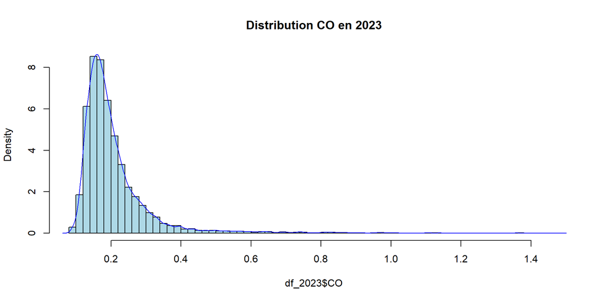

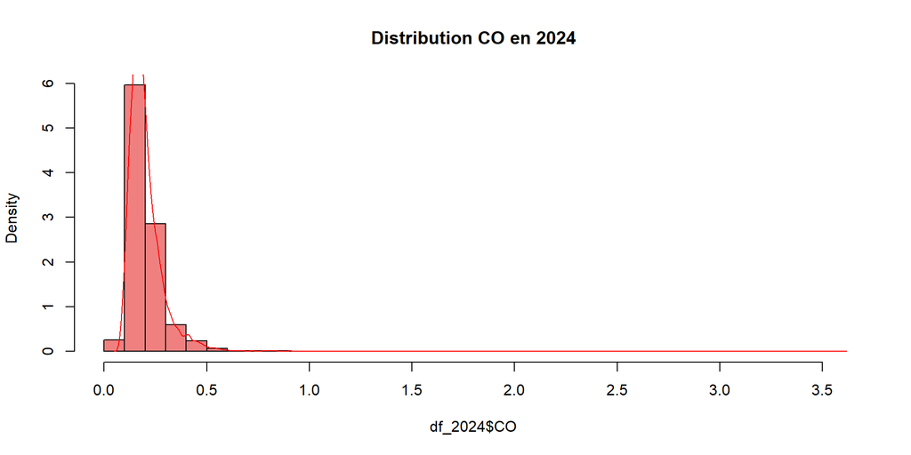

```r
# Étape 1) Visualisation de la distribution des données
hist(df_2023$CO, probability=TRUE, breaks=50, col="lightblue", main="Distribution CO en 2023")
lines(density(df_2023$CO), col="blue")

hist(df_2024$CO, probability=TRUE, breaks=50, col="lightcoral", main="Distribution CO en 2024")
lines(density(df_2024$CO), col="red")
```

**Proposition de loi n°1** : adéquation d’une loi **normale** pour les séries `df_2023` et `df_2024` de moyenne `moy_CO_2023` (resp. `moy_CO_2024`) et d’écart-type `ecart_type_2023` (resp. `ecart_type_2024`).

```r
# Correction des ex-aequos pour le test de KS
df_2023$CO <- df_2023$CO + runif(length(df_2023$CO), -1e-6, 1e-6)
df_2024$CO <- df_2024$CO + runif(length(df_2024$CO), -1e-6, 1e-6)
df_2023$CO <- df_2023$CO + runif(length(df_2023$CO), -1e-6, 1e-6)
df_2024$CO <- df_2024$CO + runif(length(df_2024$CO), -1e-6, 1e-6)

# Étape 3) Estimation des paramètres de la loi normale
moy_CO_2023 <- mean(df_2023$CO)
ecart_type_CO_2023 <- sd(df_2023$CO)

moy_CO_2024 <- mean(df_2024$CO)
ecart_type_CO_2024 <- sd(df_2024$CO)

# Étape 4) Validation avec deux tests d’adéquation

# Test de Kolmogorov Smirnov
test_KS_2023 <- ks.test(df_2023$CO, "pnorm", mean=moy_CO_2023, sd=ecart_type_CO_2023)
test_KS_2024 <- ks.test(df_2024$CO, "pnorm", mean=moy_CO_2024, sd=ecart_type_CO_2024)

test_KS_2023 <- ks.test(df_2023$CO, "pnorm", mean=mean(df_2023$CO), sd=sd(df_2023$CO))
test_KS_2024 <- ks.test(df_2024$CO, "pnorm", mean=mean(df_2024$CO), sd=sd(df_2024$CO))

# correction automatique des classes
fusionner_classes <- function(effectifs_obs, effectifs_attendus) {
  while (any(effectifs_attendus < 5)) {
    idx <- which(effectifs_attendus < 5)[1]  # Trouver la première classe problématique
    if (idx == length(effectifs_attendus)) {
      idx <- idx - 1  # Fusionner avec la classe précédente si possible
    }
    effectifs_attendus[idx] <- effectifs_attendus[idx] + effectifs_attendus[idx + 1]
    effectifs_obs[idx] <- effectifs_obs[idx] + effectifs_obs[idx + 1]

    effectifs_attendus <- effectifs_attendus[-(idx + 1)]  # Supprimer la classe fusionnée
    effectifs_obs <- effectifs_obs[-(idx + 1)]
  }
  return(list(obs = effectifs_obs, att = effectifs_attendus))
}

# nombre réduit de classes
nb_classes <- 8

# bornes des classes
bornes_2023 <- hist(df_2023$CO, breaks=nb_classes, plot=FALSE)$breaks
bornes_2024 <- hist(df_2024$CO, breaks=nb_classes, plot=FALSE)$breaks

# Calcul des effectifs observés
effectifs_obs_2023 <- hist(df_2023$CO, breaks=bornes_2023, plot=FALSE)$counts
effectifs_obs_2024 <- hist(df_2024$CO, breaks=bornes_2024, plot=FALSE)$counts

# Calcul des effectifs attendus sous loi normale
effectifs_attendus_2023 <- diff(pnorm(bornes_2023, mean=mean(df_2023$CO), sd=sd(df_2023$CO))) * length(df_2023$CO)
effectifs_attendus_2024 <- diff(pnorm(bornes_2024, mean=mean(df_2024$CO), sd=sd(df_2024$CO))) * length(df_2024$CO)

# Correction automatique des classes
res_2023 <- fusionner_classes(effectifs_obs_2023, effectifs_attendus_2023)
res_2024 <- fusionner_classes(effectifs_obs_2024, effectifs_attendus_2024)

effectifs_obs_2023 <- res_2023$obs
effectifs_attendus_2023 <- res_2023$att

effectifs_obs_2024 <- res_2024$obs
effectifs_attendus_2024 <- res_2024$att

# Normalisation de p (pour éviter kes erreurs)
effectifs_attendus_2023 <- effectifs_attendus_2023 / sum(effectifs_attendus_2023)
effectifs_attendus_2024 <- effectifs_attendus_2024 / sum(effectifs_attendus_2024)

# Test du Khi2
test_Khi2_2023 <- if (all(effectifs_attendus_2023 * sum(effectifs_obs_2023) >= 5)) {
  chisq.test(effectifs_obs_2023, p=effectifs_attendus_2023, rescale.p=TRUE)
} else {
  cat("\n Impossible d'exécuter le test du Khi2 pour 2023 car effectifs attendus insuffisants.\n")
  NA
}

test_Khi2_2024 <- if (all(effectifs_attendus_2024 * sum(effectifs_obs_2024) >= 5)) {
  chisq.test(effectifs_obs_2024, p=effectifs_attendus_2024, rescale.p=TRUE)
} else {
  cat("\n Impossible d'exécuter le test du Khi2 pour 2024 car effectifs attendus insuffisants.\n")
  NA
}

# Résultats
cat("\nTest de Kolmogorov-Smirnov pour 2023 :\n")
```

```
##
## Test de Kolmogorov-Smirnov pour 2023 :
```

```r
print(test_KS_2023)
```

```
##
##  Asymptotic one-sample Kolmogorov-Smirnov test
##
## data:  df_2023$CO
## D = 0.18557, p-value < 2.2e-16
## alternative hypothesis: two-sided
```

```r
cat("\nTest de Kolmogorov-Smirnov pour 2024 :\n")
```

```
##
## Test de Kolmogorov-Smirnov pour 2024 :
```

```r
print(test_KS_2024)
```

```
##
##  Asymptotic one-sample Kolmogorov-Smirnov test
##
## data:  df_2024$CO
## D = 0.13902, p-value < 2.2e-16
## alternative hypothesis: two-sided
```

```r
cat("\nTest du Khi² pour 2023 :\n")
```

```
##
## Test du Khi² pour 2023 :
```

```r
print(test_Khi2_2023)
```

```
##
##  Chi-squared test for given probabilities
##
## data:  effectifs_obs_2023
## X-squared = 1125.5, df = 2, p-value < 2.2e-16
```

```r
cat("\nTest du Khi² pour 2024 :\n")
```

```
##
## Test du Khi² pour 2024 :
```

```r
print(test_Khi2_2024)
```

```
##
##  Chi-squared test for given probabilities
##
## data:  effectifs_obs_2024
## X-squared = 956.54, df = 1, p-value < 2.2e-16
```

Les p-values sont extrêmement faibles (<2.2e−16), ce qui signifie que la distribution des niveaux de CO ne suit pas une loi normale.

**Proposition de loi n°2** : adéquation d’une loi **Gamma** pour les séries `df_2023` et `df_2024` de moyenne `moy_CO_2023` (resp. `moy_CO_2024`) et d’écart-type `ecart_type_2023` (resp. `ecart_type_2024`).

```r
library(MASS)  # Pour l'ajustement de la loi Gamma

# Étape 3) Estimation des paramètres de la loi gamma
parametres_gamma_2023 <- fitdistr(df_2023$CO, "gamma")
parametres_gamma_2024 <- fitdistr(df_2024$CO, "gamma")

alpha_2023 <- parametres_gamma_2023$estimate["shape"]
beta_2023 <- parametres_gamma_2023$estimate["rate"]
alpha_2024 <- parametres_gamma_2024$estimate["shape"]
beta_2024 <- parametres_gamma_2024$estimate["rate"]

# Étape 4) Validation avec deux tests d’adéquation

# Test de Kolmogorov Smirnov
test_KS_2023 <- ks.test(df_2023$CO, "pgamma", shape=alpha_2023, rate=beta_2023)
test_KS_2024 <- ks.test(df_2024$CO, "pgamma", shape=alpha_2024, rate=beta_2024)

# nombre de classes
nb_classes <- 8

bornes_2023 <- hist(df_2023$CO, breaks=nb_classes, plot=FALSE)$breaks
bornes_2024 <- hist(df_2024$CO, breaks=nb_classes, plot=FALSE)$breaks

effectifs_obs_2023 <- hist(df_2023$CO, breaks=bornes_2023, plot=FALSE)$counts
effectifs_obs_2024 <- hist(df_2024$CO, breaks=bornes_2024, plot=FALSE)$counts

effectifs_attendus_2023 <- diff(pgamma(bornes_2023, shape=alpha_2023, rate=beta_2023)) * length(df_2023$CO)
effectifs_attendus_2024 <- diff(pgamma(bornes_2024, shape=alpha_2024, rate=beta_2024)) * length(df_2024$CO)

# fusion des classes si effectifs trop faibles
fusionner_classes <- function(effectifs_obs, effectifs_attendus) {
  while (any(effectifs_attendus < 5)) {
    idx <- which(effectifs_attendus < 5)[1]
    if (idx == length(effectifs_attendus)) {
      idx <- idx - 1
    }
    effectifs_attendus[idx] <- effectifs_attendus[idx] + effectifs_attendus[idx + 1]
    effectifs_obs[idx] <- effectifs_obs[idx] + effectifs_obs[idx + 1]

    effectifs_attendus <- effectifs_attendus[-(idx + 1)]
    effectifs_obs <- effectifs_obs[-(idx + 1)]
  }
  return(list(obs = effectifs_obs, att = effectifs_attendus))
}

# fusion des classes si nécessaire
res_2023 <- fusionner_classes(effectifs_obs_2023, effectifs_attendus_2023)
res_2024 <- fusionner_classes(effectifs_obs_2024, effectifs_attendus_2024)

effectifs_obs_2023 <- res_2023$obs
effectifs_attendus_2023 <- res_2023$att
effectifs_obs_2024 <- res_2024$obs
effectifs_attendus_2024 <- res_2024$att

# normalisation du test du Khi2
effectifs_attendus_2023 <- effectifs_attendus_2023 / sum(effectifs_attendus_2023)
effectifs_attendus_2024 <- effectifs_attendus_2024 / sum(effectifs_attendus_2024)

# Test du Khi2
test_Khi2_2023 <- if (all(effectifs_attendus_2023 * sum(effectifs_obs_2023) >= 5)) {
  chisq.test(effectifs_obs_2023, p=effectifs_attendus_2023, rescale.p=TRUE)
} else {
  cat("\n Impossible d'exécuter le test du Khi2 pour 2023 car effectifs attendus insuffisants.\n")
  NA
}

test_Khi2_2024 <- if (all(effectifs_attendus_2024 * sum(effectifs_obs_2024) >= 5)) {
  chisq.test(effectifs_obs_2024, p=effectifs_attendus_2024, rescale.p=TRUE)
} else {
  cat("\n Impossible d'exécuter le test du Khi2 pour 2024 car effectifs attendus insuffisants.\n")
  NA
}

# Résultats
cat("\n Paramètres de la loi Gamma pour 2023 :\n")
```

```
##
##  Paramètres de la loi Gamma pour 2023 :
```

```r
print(parametres_gamma_2023)
```

```
##       shape         rate
##    6.32933744   30.32386840
##  ( 0.09448932) ( 0.47114084)
```

```r
cat("\n Paramètres de la loi Gamma pour 2024 :\n")
```

```
##
##  Paramètres de la loi Gamma pour 2024 :
```

```r
print(parametres_gamma_2024)
```

```
##      shape         rate
##    7.1857503   35.7044267
##  ( 0.1064982) ( 0.5480888)
```

```r
cat("\nTest de Kolmogorov-Smirnov pour 2023 :\n")
```

```
##
## Test de Kolmogorov-Smirnov pour 2023 :
```

```r
print(test_KS_2023)
```

```
##
##  Asymptotic one-sample Kolmogorov-Smirnov test
##
## data:  df_2023$CO
## D = 0.12513, p-value < 2.2e-16
## alternative hypothesis: two-sided
```

```r
cat("\nTest de Kolmogorov-Smirnov pour 2024 :\n")
```

```
##
## Test de Kolmogorov-Smirnov pour 2024 :
```

```r
print(test_KS_2024)
```

```
##
##  Asymptotic one-sample Kolmogorov-Smirnov test
##
## data:  df_2024$CO
## D = 0.080768, p-value < 2.2e-16
## alternative hypothesis: two-sided
```

```r
cat("\nTest du Khi² pour 2023 :\n")
```

```
##
## Test du Khi² pour 2023 :
```

```r
print(test_Khi2_2023)
```

```
##
##  Chi-squared test for given probabilities
##
## data:  effectifs_obs_2023
## X-squared = 691.88, df = 2, p-value < 2.2e-16
```

```r
cat("\nTest du Khi² pour 2024 :\n")
```

```
##
## Test du Khi² pour 2024 :
```

```r
print(test_Khi2_2024)
```

```
##
##  Chi-squared test for given probabilities
##
## data:  effectifs_obs_2024
## X-squared = 493.48, df = 1, p-value < 2.2e-16
```

Les p-values sont extrêmement faibles (<2.2e−16), ce qui signifie que la distribution des niveaux de CO ne suit pas une loi gamma.

**Proposition de loi n°3** : adéquation d’une loi **log-normale** pour les séries `df_2023` et `df_2024` de moyenne `moy_CO_2023` (resp. `moy_CO_2024`) et d’écart-type `ecart_type_2023` (resp. `ecart_type_2024`).

```r
# Étape 3) Estimation des paramètres de la loi log normale
parametres_lognorm_2023 <- fitdistr(df_2023$CO, "lognormal")
parametres_lognorm_2024 <- fitdistr(df_2024$CO, "lognormal")

mu_2023 <- parametres_lognorm_2023$estimate["meanlog"]
sigma_2023 <- parametres_lognorm_2023$estimate["sdlog"]
mu_2024 <- parametres_lognorm_2024$estimate["meanlog"]
sigma_2024 <- parametres_lognorm_2024$estimate["sdlog"]

# Étape 4) Validation avec deux tests d’adéquation

# Test de Kolmogorov Smirnov
test_KS_2023 <- ks.test(df_2023$CO, "plnorm", meanlog=mu_2023, sdlog=sigma_2023)
test_KS_2024 <- ks.test(df_2024$CO, "plnorm", meanlog=mu_2024, sdlog=sigma_2024)

# nombre de classes
nb_classes <- 8

bornes_2023 <- hist(df_2023$CO, breaks=nb_classes, plot=FALSE)$breaks
bornes_2024 <- hist(df_2024$CO, breaks=nb_classes, plot=FALSE)$breaks

effectifs_obs_2023 <- hist(df_2023$CO, breaks=bornes_2023, plot=FALSE)$counts
effectifs_obs_2024 <- hist(df_2024$CO, breaks=bornes_2024, plot=FALSE)$counts

effectifs_attendus_2023 <- diff(plnorm(bornes_2023, meanlog=mu_2023, sdlog=sigma_2023)) * length(df_2023$CO)
effectifs_attendus_2024 <- diff(plnorm(bornes_2024, meanlog=mu_2024, sdlog=sigma_2024)) * length(df_2024$CO)

# fusion des classes si effectifs trop faibles
fusionner_classes <- function(effectifs_obs, effectifs_attendus) {
  while (any(effectifs_attendus < 5)) {
    idx <- which(effectifs_attendus < 5)[1]
    if (idx == length(effectifs_attendus)) {
      idx <- idx - 1
    }
    effectifs_attendus[idx] <- effectifs_attendus[idx] + effectifs_attendus[idx + 1]
    effectifs_obs[idx] <- effectifs_obs[idx] + effectifs_obs[idx + 1]

    effectifs_attendus <- effectifs_attendus[-(idx + 1)]
    effectifs_obs <- effectifs_obs[-(idx + 1)]
  }
  return(list(obs = effectifs_obs, att = effectifs_attendus))
}

# fusion des classes si nécessaire
res_2023 <- fusionner_classes(effectifs_obs_2023, effectifs_attendus_2023)
res_2024 <- fusionner_classes(effectifs_obs_2024, effectifs_attendus_2024)

effectifs_obs_2023 <- res_2023$obs
effectifs_attendus_2023 <- res_2023$att

effectifs_obs_2024 <- res_2024$obs
effectifs_attendus_2024 <- res_2024$att

# normalisation du test du Khi2
effectifs_attendus_2023 <- effectifs_attendus_2023 / sum(effectifs_attendus_2023)
effectifs_attendus_2024 <- effectifs_attendus_2024 / sum(effectifs_attendus_2024)

# Test du Khi2
test_Khi2_2023 <- if (all(effectifs_attendus_2023 * sum(effectifs_obs_2023) >= 5)) {
  chisq.test(effectifs_obs_2023, p=effectifs_attendus_2023, rescale.p=TRUE)
} else {
  cat("\n Impossible d'exécuter le test du Khi² pour 2023, effectifs attendus insuffisants.\n")
  NA
}

test_Khi2_2024 <- if (all(effectifs_attendus_2024 * sum(effectifs_obs_2024) >= 5)) {
  chisq.test(effectifs_obs_2024, p=effectifs_attendus_2024, rescale.p=TRUE)
} else {
  cat("\n Impossible d'exécuter le test du Khi² pour 2024, effectifs attendus insuffisants.\n")
  NA
}

# Résultats
cat("\n Paramètres de la loi Log-Normale pour 2023 :\n")
```

```
##
##  Paramètres de la loi Log-Normale pour 2023 :
```

```r
print(parametres_lognorm_2023)
```

```
##      meanlog         sdlog
##   -1.647802314    0.366356405
##  ( 0.003967397) ( 0.002805373)
```

```r
cat("\n Paramètres de la loi Log-Normale pour 2024 :\n")
```

```
##
##  Paramètres de la loi Log-Normale pour 2024 :
```

```r
print(parametres_lognorm_2024)
```

```
##      meanlog         sdlog
##   -1.674338800    0.358220871
##  ( 0.003839869) ( 0.002715197)
```

```r
cat("\nTest de Kolmogorov-Smirnov pour 2023 :\n")
```

```
##
## Test de Kolmogorov-Smirnov pour 2023 :
```

```r
print(test_KS_2023)
```

```
##
##  Asymptotic one-sample Kolmogorov-Smirnov test
##
## data:  df_2023$CO
## D = 0.090789, p-value < 2.2e-16
## alternative hypothesis: two-sided
```

```r
cat("\nTest de Kolmogorov-Smirnov pour 2024 :\n")
```

```
##
## Test de Kolmogorov-Smirnov pour 2024 :
```

```r
print(test_KS_2024)
```

```
##
##  Asymptotic one-sample Kolmogorov-Smirnov test
##
## data:  df_2024$CO
## D = 0.051251, p-value < 2.2e-16
## alternative hypothesis: two-sided
```

```r
cat("\nTest du Khi² pour 2023 :\n")
```

```
##
## Test du Khi² pour 2023 :
```

```r
print(test_Khi2_2023)
```

```
##
##  Chi-squared test for given probabilities
##
## data:  effectifs_obs_2023
## X-squared = 2489.8, df = 3, p-value < 2.2e-16
```

```r
cat("\nTest du Khi² pour 2024 :\n")
```

```
##
## Test du Khi² pour 2024 :
```

```r
print(test_Khi2_2024)
```

```
##
##  Chi-squared test for given probabilities
##
## data:  effectifs_obs_2024
## X-squared = 149.38, df = 1, p-value < 2.2e-16
```

Une fois de plus, les p-values sont extrêmement faibles (<2.2e−16), ce qui signifie que la distribution des niveaux de CO ne suit pas une loi log-normale.

Proposons une dernière loi, la loi exponentielle.

**Proposition de loi n°4** : adéquation d’une loi **exponentielle** pour les séries `df_2023` et `df_2024`, avec un paramètre $\lambda$ estimé comme l’inverse de la moyenne `moy_CO_2023` (resp. `moy_CO_2024`) et d’écart-type estimé comme l’inverse de $\lambda$.

```r
# Étape 3) Estimation des paramètres de la loi exponentielle
lambda_2023 <- 1 / mean(df_2023$CO)
lambda_2024 <- 1 / mean(df_2024$CO)

# Étape 4) Validation avec deux tests d’adéquation

# Test de Kolmogorov Smirnov
test_KS_2023 <- ks.test(df_2023$CO, "pexp", rate=lambda_2023)
test_KS_2024 <- ks.test(df_2024$CO, "pexp", rate=lambda_2024)

# nombre de classes
nb_classes <- 8

bornes_2023 <- hist(df_2023$CO, breaks=nb_classes, plot=FALSE)$breaks
bornes_2024 <- hist(df_2024$CO, breaks=nb_classes, plot=FALSE)$breaks

effectifs_obs_2023 <- hist(df_2023$CO, breaks=bornes_2023, plot=FALSE)$counts
effectifs_obs_2024 <- hist(df_2024$CO, breaks=bornes_2024, plot=FALSE)$counts

effectifs_attendus_2023 <- diff(pexp(bornes_2023, rate=lambda_2023)) * length(df_2023$CO)
effectifs_attendus_2024 <- diff(pexp(bornes_2024, rate=lambda_2024)) * length(df_2024$CO)

# fusion des classes si effectifs trop faibles
fusionner_classes <- function(effectifs_obs, effectifs_attendus) {
  while (any(effectifs_attendus < 5)) {
    idx <- which(effectifs_attendus < 5)[1]
    if (idx == length(effectifs_attendus)) {
      idx <- idx - 1
    }
    effectifs_attendus[idx] <- effectifs_attendus[idx] + effectifs_attendus[idx + 1]
    effectifs_obs[idx] <- effectifs_obs[idx] + effectifs_obs[idx + 1]

    effectifs_attendus <- effectifs_attendus[-(idx + 1)]
    effectifs_obs <- effectifs_obs[-(idx + 1)]
  }
  return(list(obs = effectifs_obs, att = effectifs_attendus))
}

# fusion des classes si nécessaire
res_2023 <- fusionner_classes(effectifs_obs_2023, effectifs_attendus_2023)
res_2024 <- fusionner_classes(effectifs_obs_2024, effectifs_attendus_2024)

effectifs_obs_2023 <- res_2023$obs
effectifs_attendus_2023 <- res_2023$att

effectifs_obs_2024 <- res_2024$obs
effectifs_attendus_2024 <- res_2024$att

# normalisation du test du Khi2
effectifs_attendus_2023 <- effectifs_attendus_2023 / sum(effectifs_attendus_2023)
effectifs_attendus_2024 <- effectifs_attendus_2024 / sum(effectifs_attendus_2024)

# Test du Khi2
test_Khi2_2023 <- if (all(effectifs_attendus_2023 * sum(effectifs_obs_2023) >= 5)) {
  chisq.test(effectifs_obs_2023, p=effectifs_attendus_2023, rescale.p=TRUE)
} else {
  cat("\n Impossible d'exécuter le test du Khi² pour 2023, effectifs attendus insuffisants.\n")
  NA
}

test_Khi2_2024 <- if (all(effectifs_attendus_2024 * sum(effectifs_obs_2024) >= 5)) {
  chisq.test(effectifs_obs_2024, p=effectifs_attendus_2024, rescale.p=TRUE)
} else {
  cat("\n Impossible d'exécuter le test du Khi² pour 2024, effectifs attendus insuffisants.\n")
  NA
}

# Résultats
cat("\n Paramètre de la loi Exponentielle pour 2023 (lambda) :\n", lambda_2023, "\n")
```

```
##
##  Paramètre de la loi Exponentielle pour 2023 (lambda) :
##  4.791058
```

```r
cat("\n Paramètre de la loi Exponentielle pour 2024 (lambda) :\n", lambda_2024, "\n")
```

```
##
##  Paramètre de la loi Exponentielle pour 2024 (lambda) :
##  4.968696
```

```r
cat("\nTest de Kolmogorov-Smirnov pour 2023 :\n")
```

```
##
## Test de Kolmogorov-Smirnov pour 2023 :
```

```r
print(test_KS_2023)
```

```
##
##  Asymptotic one-sample Kolmogorov-Smirnov test
##
## data:  df_2023$CO
## D = 0.40097, p-value < 2.2e-16
## alternative hypothesis: two-sided
```

```r
cat("\nTest de Kolmogorov-Smirnov pour 2024 :\n")
```

```
##
## Test de Kolmogorov-Smirnov pour 2024 :
```

```r
print(test_KS_2024)
```

```
##
##  Asymptotic one-sample Kolmogorov-Smirnov test
##
## data:  df_2024$CO
## D = 0.37429, p-value < 2.2e-16
## alternative hypothesis: two-sided
```

```r
cat("\nTest du Khi² pour 2023 :\n")
```

```
##
## Test du Khi² pour 2023 :
```

```r
print(test_Khi2_2023)
```

```
##
##  Chi-squared test for given probabilities
##
## data:  effectifs_obs_2023
## X-squared = 924.4, df = 7, p-value < 2.2e-16
```

```r
cat("\nTest du Khi² pour 2024 :\n")
```

```
##
## Test du Khi² pour 2024 :
```

```r
print(test_Khi2_2024)
```

```
##
##  Chi-squared test for given probabilities
##
## data:  effectifs_obs_2024
## X-squared = 607.91, df = 3, p-value < 2.2e-16
```

Une fois de plus, les p-values sont extrêmement faibles (<2.2e−16), ce qui signifie que la distribution des niveaux de CO ne suit pas une loi exponentielle.

Après quatre propositions de distributions pour nos données, on peut conclure que nos données ne semblent pas suivre une loi usuelle.

**————————————————————————————— Question 11 ————————————————————————————–**

Protocole de contrôle qualité sur la première série :

On utilise la série 2023 comme référence et on estime :

- la moyenne $\bar{X}$
- l’écart-type $\sigma$
- les limites de contrôle supérieure (UCL) et inférieure (LCL) définies comme :

$$UCL = \bar{X} + 3 \sigma \text{et} LCL = \bar{X} - 3 \sigma$$

Implémentons la carte sur la première série, 2023 :

Nous avons identifié précédemment une loi log-normale comme étant la meilleure distribution pour modéliser la série 2023 (parmi celles testées plus haut, bien que les tests d’adéquation n’étaient pas concluants).

```r
# Analyse des données
summary(df_2023$CO)  # Statistiques descriptives
```

```
##    Min. 1st Qu.  Median    Mean 3rd Qu.    Max.
##  0.0860  0.1510  0.1800  0.2087  0.2270  1.4760
```

```r
# Ajustement à la loi log-normale
ajustement_lognormale <- fitdistr(df_2023$CO, "lognormal")

# Test de Kolmogorov-Smirnov
ks_test_lognormale <- ks.test(df_2023$CO, "plnorm", meanlog=ajustement_lognormale$estimate[1], sdlog=ajustement_lognormale$estimate[2])

# Sélection de la loi avec le plus grand p-value
p_value <- ks_test_lognormale$p.value
loi <- "Log-Normale"

cat("\n Loi sélectionnée pour modéliser la série 2023 :", loi, "\n")
```

```
##
##  Loi sélectionnée pour modéliser la série 2023 : Log-Normale
```

```r
# Limites de contrôle
mu <- ajustement_lognormale$estimate[1]
sigma <- ajustement_lognormale$estimate[2]
UCL <- qlnorm(0.999, meanlog=mu, sdlog=sigma)
LCL <- qlnorm(0.001, meanlog=mu, sdlog=sigma)

cat("\n Limites de contrôle définies :\n")
```

```
##
##  Limites de contrôle définies :
```

```r
cat("UCL =", UCL, " LCL =", LCL, "\n")
```

```
## UCL = 0.5970969  LCL = 0.06204293
```

```r
# Carte de contrôle
donnees_2023 <- df_2023$CO
carte_controle_2023 <- qcc(donnees_2023, type="xbar.one", data.name="Niveau de CO en 2023")

# Vérification des valeurs hors contrôle
hors_controle_2023 <- donnees_2023[donnees_2023 < LCL | donnees_2023 > UCL]
nombre_hors_controle <- length(hors_controle_2023)

cat("\n Vérification des valeurs hors contrôle :\n")
```

```
##
##  Vérification des valeurs hors contrôle :
```

```r
cat("Nombre de valeurs hors contrôle =", nombre_hors_controle, "\n")
```

```
## Nombre de valeurs hors contrôle = 143
```

```r
if (nombre_hors_controle == 0) {
  cat("\n Le processus est sous contrôle.\n")
} else {
  cat("\n Le processsus n'est pas sous contrôle -> Analyse requise\n")
}
```

```
##
##  Le processsus n'est pas sous contrôle -> Analyse requise
```

[figure not shown]

Il y a 143 valeurs hors contrôle, ce qui reste énorme.

On vérifie si la deuxième série est sous contrôle :

```r
# loi log-normale sur la série 2024
ajustement_lognormale_2024 <- fitdistr(df_2024$CO, "lognormal")

mu_2024 <- ajustement_lognormale_2024$estimate["meanlog"]
sigma_2024 <- ajustement_lognormale_2024$estimate["sdlog"]

# Calcul des limites hors controle
UCL_2024 <- qlnorm(0.999, meanlog=mu_2024, sdlog=sigma_2024)
LCL_2024 <- qlnorm(0.001, meanlog=mu_2024, sdlog=sigma_2024)

cat("\n Loi sélectionnée pour la série 2024 : Log-Normale\n")
```

```
##
##  Loi sélectionnée pour la série 2024 : Log-Normale
```

```r
cat("UCL 2024 =", UCL_2024, " LCL 2024 =", LCL_2024, "\n")
```

```
## UCL 2024 = 0.5670243  LCL 2024 = 0.06195639
```

```r
# detection des valeurs hors contrôle
hors_controle_2024 <- df_2024$CO[df_2024$CO < LCL_2024 | df_2024$CO > UCL_2024]
nombre_hors_controle_2024 <- length(hors_controle_2024)

cat("\n Vérification des valeurs hors contrôle pour 2024 :\n")
```

```
##
##  Vérification des valeurs hors contrôle pour 2024 :
```

```r
cat("Nombre de valeurs hors contrôle =", nombre_hors_controle_2024, "\n")
```

```
## Nombre de valeurs hors contrôle = 48
```

```r
if (nombre_hors_controle_2024 == 0) {
  cat("\n La série 2024 est sous contrôle.\n")
} else {
  cat("\n Le processsus n'est pas sous contrôle -> Analyse requise\n")
}
```

```
##
##  Le processsus n'est pas sous contrôle -> Analyse requise
```

```
##
## Call:
## qcc(data = df_2024$CO, type = "xbar.one", data.name = "Niveau de CO en 2024")
##
## xbar.one chart for Niveau de CO en 2024
##
## Summary of group statistics:
##     Min.  1st Qu.   Median     Mean  3rd Qu.     Max.
## 0.074001 0.148999 0.181000 0.201260 0.229000 3.590000
##
## Group sample size:  1
## Number of groups:  8703
## Center of group statistics:  0.20126
## Standard deviation:  0.01626809
##
## Control limits:
##        LCL       UCL
##  0.1524558 0.2500643
```

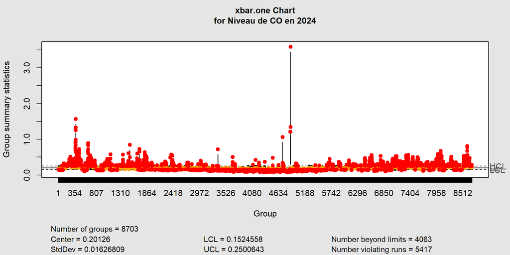

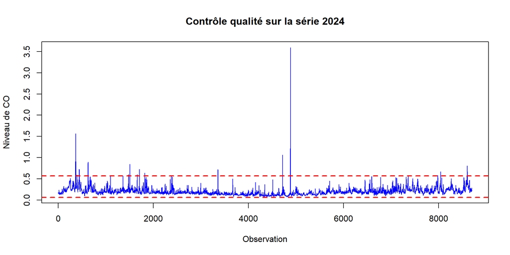

```r
# Carte de contrôle
carte_controle_2024 <- qcc(df_2024$CO, type="xbar.one",
                           data.name="Niveau de CO en 2024")

plot(df_2024$CO, type="l", col="blue", main="Contrôle qualité sur la série 2024",
     ylab="Niveau de CO", xlab="Observation")
abline(h=UCL_2024, col="red", lty=2, lwd=2)  # Limite supérieure
abline(h=LCL_2024, col="red", lty=2, lwd=2)  # Limite inférieure


# Stats descriptives
summary(carte_controle_2024)
```